# Introduction

Google Trends gives us an estimate of search volume. Let's explore if search popularity relates to other kinds of data. Perhaps there are patterns in Google's search volume and the price of Bitcoin or a hot stock like Tesla. Perhaps search volume for the term "Unemployment Benefits" can tell us something about the actual unemployment rate?

Data Sources:

- [Unemployment Rate from FRED](https://fred.stlouisfed.org/series/UNRATE/)
- [Google Trends](https://trends.google.com/trends/explore)
- [Yahoo Finance for Tesla Stock Price](https://finance.yahoo.com/quote/TSLA/history?p=TSLA)
- [Yahoo Finance for Bitcoin Stock Price](https://finance.yahoo.com/quote/BTC-USD/history?p=BTC-USD)

# Import Statements

# Read the Data

# Data Exploration

### Tesla

## Dataset Exploration

Examining the shape, column types, descriptive statistics, and periodicity of each dataset to establish the structure and time frequency before cleaning and resampling.

```
Tesla describe:
       TSLA_WEB_SEARCH  TSLA_USD_CLOSE
count           124.00          124.00
mean              8.73           50.96
std               5.87           65.91
min               2.00            3.90
25%               3.75            7.35
50%               8.00           44.65
75%              12.00           58.99
max              31.00          498.32
------------------------------------------------------------
Tesla info:
<class 'pandas.core.frame.DataFrame'>
RangeIndex: 124 entries, 0 to 123
Data columns (total 3 columns):
 #   Column           Non-Null Count  Dtype
---  ------           --------------  -----
 0   MONTH            124 non-null    object
 1   TSLA_WEB_SEARCH  124 non-null    int64
 2   TSLA_USD_CLOSE   124 non-null    float64
dtypes: float64(1), int64(1), object(1)
memory usage: 3.0+ KB
None
```

```
Bitcoin search describe:

       BTC_NEWS_SEARCH
count            73.00
mean             15.01
std              15.15
min               3.00
25%               5.00
50%              14.00
75%              18.00
max             100.00
------------------------------------------------------------
Bitcoin search info:

<class 'pandas.core.frame.DataFrame'>
RangeIndex: 73 entries, 0 to 72
Data columns (total 2 columns):
 #   Column           Non-Null Count  Dtype
---  ------           --------------  -----
 0   MONTH            73 non-null     object
 1   BTC_NEWS_SEARCH  73 non-null     int64
dtypes: int64(1), object(1)
memory usage: 1.3+ KB
None
```

```
Bitcoin price head:

         DATE  CLOSE        VOLUME
0  2014-09-17 457.33 21,056,800.00
1  2014-09-18 424.44 34,483,200.00
2  2014-09-19 394.80 37,919,700.00
3  2014-09-20 408.90 36,863,600.00
4  2014-09-21 398.82 26,580,100.00
------------------------------------------------------------
Bitcoin price info:

<class 'pandas.core.frame.DataFrame'>
RangeIndex: 2204 entries, 0 to 2203
Data columns (total 3 columns):
 #   Column  Non-Null Count  Dtype
---  ------  --------------  -----
 0   DATE    2204 non-null   object
 1   CLOSE   2203 non-null   float64
 2   VOLUME  2203 non-null   float64
dtypes: float64(2), object(1)
memory usage: 51.8+ KB
None
------------------------------------------------------------
Bitcoin price describe:

          CLOSE            VOLUME
count  2,203.00          2,203.00
mean   4,429.42  8,043,622,390.14
std    4,148.15 11,765,285,602.39
min      178.10      5,914,570.00
25%      433.63     60,299,150.00
50%    3,637.52  2,018,889,984.00
75%    7,997.37 13,224,781,071.00
max   19,497.40 74,156,772,074.00
```

```
DF Unemployment head:

     MONTH  UE_BENEFITS_WEB_SEARCH  UNRATE
0  2004-01                      34    5.70
1  2004-02                      33    5.60
2  2004-03                      25    5.80
3  2004-04                      29    5.60
4  2004-05                      23    5.60
------------------------------------------------------------
Bitcoin price info:

<class 'pandas.core.frame.DataFrame'>
RangeIndex: 181 entries, 0 to 180
Data columns (total 3 columns):
 #   Column                  Non-Null Count  Dtype
---  ------                  --------------  -----
 0   MONTH                   181 non-null    object
 1   UE_BENEFITS_WEB_SEARCH  181 non-null    int64
 2   UNRATE                  181 non-null    float64
dtypes: float64(1), int64(1), object(1)
memory usage: 4.4+ KB
None
------------------------------------------------------------
Bitcoin price describe:

       UE_BENEFITS_WEB_SEARCH  UNRATE
count                  181.00  181.00
mean                    35.11    6.22
std                     20.48    1.89
min                     14.00    3.70
25%                     21.00    4.70
50%                     26.00    5.40
75%                     45.00    7.80
max                    100.00   10.00
```

```
Largest value for Tesla in Web Search: 31
Smallest value for Tesla in Web Search: 2
```

### Unemployment Data

```
Largest value for "Unemployemnt Benefits" in Web Search: 100
```

### Bitcoin

```
largest BTC News Search:
100
```

# Data Cleaning

### Check for Missing Values

### Missing Value Check

Checking each DataFrame for null entries before analysis. The Bitcoin price history contains one missing row that must be removed before resampling.

```
Missing values for Tesla?:
MONTH              0
TSLA_WEB_SEARCH    0
TSLA_USD_CLOSE     0
dtype: int64
Missing values for U/E?:
MONTH                     0
UE_BENEFITS_WEB_SEARCH    0
UNRATE                    0
dtype: int64
Missing values for BTC Search?:
MONTH              0
BTC_NEWS_SEARCH    0
dtype: int64
```

|  | DATE | CLOSE | VOLUME |
| --- | --- | --- | --- |
| 0 | 2014-09-17 | 457.33 | 21,056,800.00 |
| 1 | 2014-09-18 | 424.44 | 34,483,200.00 |
| 2 | 2014-09-19 | 394.80 | 37,919,700.00 |
| 3 | 2014-09-20 | 408.90 | 36,863,600.00 |
| 4 | 2014-09-21 | 398.82 | 26,580,100.00 |

```
Missing values for BTC price?:
DATE      0
CLOSE     1
VOLUME    1
dtype: int64
```

```
take a closer look at the missing values in BTC price:
            DATE  CLOSE  VOLUME
2148  2020-08-04    NaN     NaN
```

```
Number of missing values: 2
```

### Dropping Missing Values

Dropping the single null row identified in the Bitcoin price data to produce a clean, complete time series before the resampling step.

```
Number of missing values: 0
```

### Converting Date Strings to Datetime

All date columns arrive as plain strings. Converting them to pandas Timestamp objects enables resampling, rolling windows, and Matplotlib date formatting on the time axis.

```
df_tesla MONTH
dtype: datetime64[ns]
sample value type: <class 'pandas._libs.tslibs.timestamps.Timestamp'>

df_btc_price DATE
dtype: datetime64[ns]
sample value type: <class 'pandas._libs.tslibs.timestamps.Timestamp'>

df_btc_search MONTH
dtype: datetime64[ns]
sample value type: <class 'pandas._libs.tslibs.timestamps.Timestamp'>

df_unemployment MONTH
dtype: datetime64[ns]
sample value type: <class 'pandas._libs.tslibs.timestamps.Timestamp'>
```

### Converting from Daily to Monthly Data

[Pandas .resample() documentation](https://pandas.pydata.org/pandas-docs/stable/reference/api/pandas.DataFrame.resample.html)

|  | DATE | CLOSE | VOLUME |
| --- | --- | --- | --- |
| 0 | 2014-09-17 | 457.33 | 21,056,800.00 |
| 1 | 2014-09-18 | 424.44 | 34,483,200.00 |
| 2 | 2014-09-19 | 394.80 | 37,919,700.00 |
| 3 | 2014-09-20 | 408.90 | 36,863,600.00 |
| 4 | 2014-09-21 | 398.82 | 26,580,100.00 |

```
(73, 2)
```

| DATE | CLOSE | VOLUME |
| --- | --- | --- |
| 2014-09-30 | 386.94 | 34,707,300.00 |
| 2014-10-31 | 338.32 | 12,545,400.00 |
| 2014-11-30 | 378.05 | 9,194,440.00 |
| 2014-12-31 | 320.19 | 13,942,900.00 |
| 2015-01-31 | 217.46 | 23,348,200.00 |

# Data Visualisation

### Notebook Formatting & Style Helpers

### Tesla Stock Price v.s. Search Volume

### Tesla: Initial Dual-Axis Chart

Plotting Tesla stock price against Google search volume on two independent y-axes using `twinx()` — the first visual test of whether the two signals share any visible pattern over the same period.

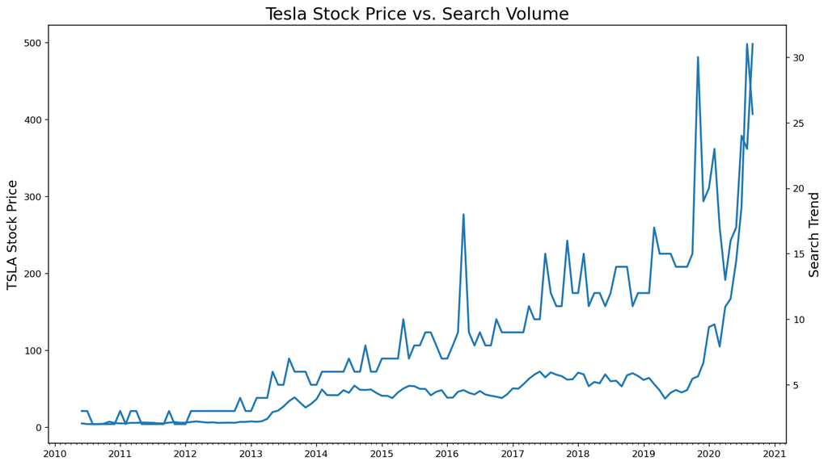

### Tesla: Colour-Coded Dual-Axis Chart

Applying colour coding to distinguish the two signals — red for stock price, blue for search volume — and matching axis label colours to their corresponding lines for immediate visual association.

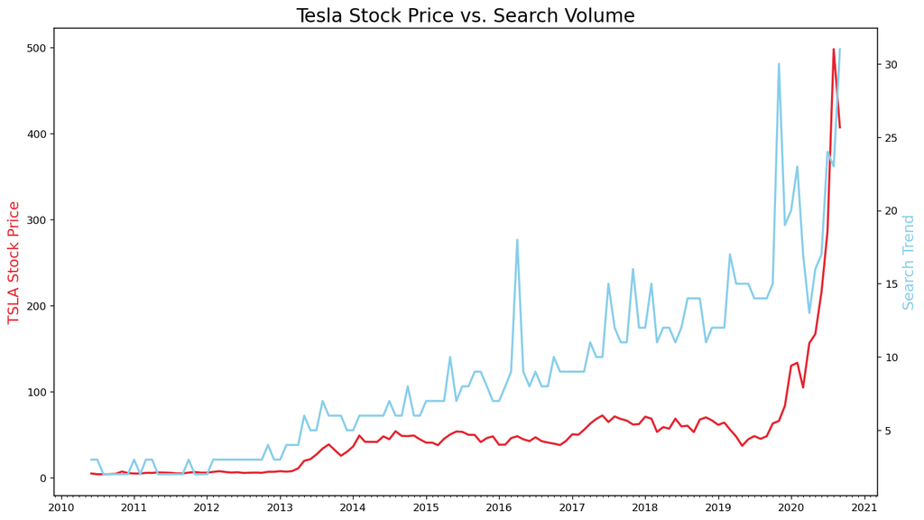

### Tesla: Final Styled Chart

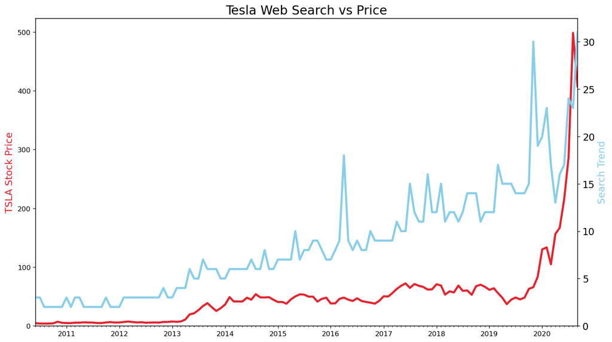

How to add tick formatting for dates on the x-axis.

### Bitcoin (BTC) Price v.s. Search Volume

### Bitcoin: Price vs. Search Volume

Comparing resampled month-end Bitcoin prices against monthly search volume on a dual-axis chart. A dashed line for price and circle markers for search visually separate the two signals and make the lead-lag relationship easier to read.

|  | MONTH | BTC_NEWS_SEARCH |
| --- | --- | --- |
| count | 73 | 73.00 |
| mean | 2017-08-31 09:32:03.287671296 | 15.01 |
| min | 2014-09-01 00:00:00 | 3.00 |
| 25% | 2016-03-01 00:00:00 | 5.00 |
| 50% | 2017-09-01 00:00:00 | 14.00 |
| 75% | 2019-03-01 00:00:00 | 18.00 |
| max | 2020-09-01 00:00:00 | 100.00 |
| std | NaN | 15.15 |

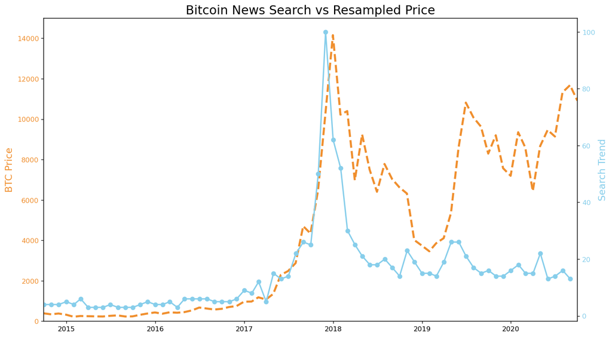

### Unemployement Benefits Search vs. Actual Unemployment in the U.S.

### Unemployment: Search vs. Rate (2004–2019)

Plotting 'unemployment benefits' search interest against the official FRED unemployment rate on a dual-axis chart. A grey dashed grid aids reading across the long time axis and surfaces the seasonal search pattern that recurs each year.

|  | MONTH | UE_BENEFITS_WEB_SEARCH | UNRATE |
| --- | --- | --- | --- |
| count | 181 | 181.00 | 181.00 |
| mean | 2011-07-02 01:51:22.872928256 | 35.11 | 6.22 |
| min | 2004-01-01 00:00:00 | 14.00 | 3.70 |
| 25% | 2007-10-01 00:00:00 | 21.00 | 4.70 |
| 50% | 2011-07-01 00:00:00 | 26.00 | 5.40 |
| 75% | 2015-04-01 00:00:00 | 45.00 | 7.80 |
| max | 2019-01-01 00:00:00 | 100.00 | 10.00 |
| std | NaN | 20.48 | 1.89 |

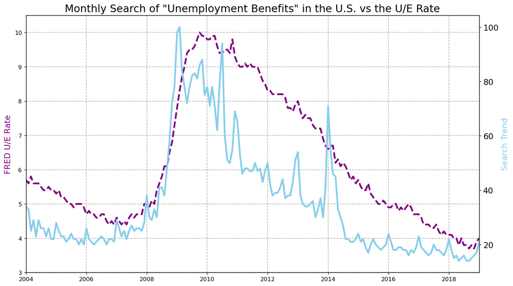

### Unemployment: 6-Month Rolling Average

Applying a 6-month rolling mean to the unemployment search data smooths out seasonal spikes. The smoothed signal exposes the structural employment trend beneath the noise — and shows more clearly which series moves first.

|  | MONTH | UE_BENEFITS_WEB_SEARCH | UE_SEARCH_6M_AVG |
| --- | --- | --- | --- |
| 0 | 2004-01-01 | 34 | NaN |
| 1 | 2004-02-01 | 33 | NaN |
| 2 | 2004-03-01 | 25 | NaN |
| 3 | 2004-04-01 | 29 | NaN |
| 4 | 2004-05-01 | 23 | NaN |
| 5 | 2004-06-01 | 29 | 28.83 |
| 6 | 2004-07-01 | 26 | 27.50 |
| 7 | 2004-08-01 | 26 | 26.33 |
| 8 | 2004-09-01 | 23 | 26.00 |
| 9 | 2004-10-01 | 26 | 25.50 |

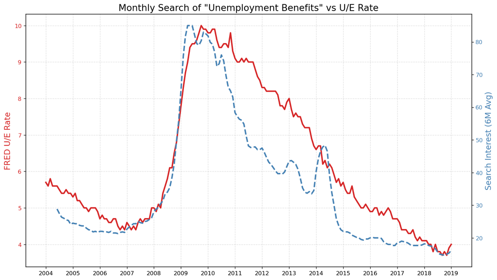

### Including 2020 in Unemployment Charts

### Unemployment: Adding the 2020 COVID Dataset

Extending the dataset through 2020 captures the COVID-19 shock. Adding this data also triggers Google Trends normalisation — index values are rescaled to 100 within the new time window, compressing the entire 2004–2019 baseline.

|  | MONTH | UE_BENEFITS_WEB_SEARCH | UNRATE |
| --- | --- | --- | --- |
| 0 | 2004-01-01 | 9 | 5.70 |
| 1 | 2004-02-01 | 8 | 5.60 |
| 2 | 2004-03-01 | 7 | 5.80 |
| 3 | 2004-04-01 | 8 | 5.60 |
| 4 | 2004-05-01 | 6 | 5.60 |

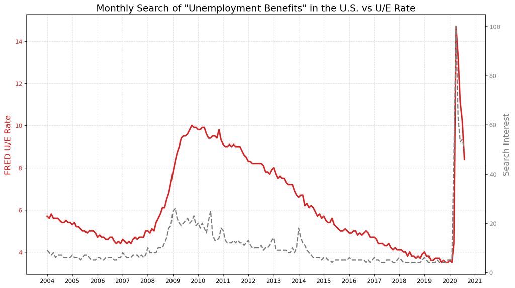

## Key Findings

**COVID-19 unemployment shock (2020)**  
The 2020 dataset compresses a pattern that normally unfolds over quarters into a matter of weeks. Search interest for 'unemployment benefits' and the official FRED unemployment rate spiked simultaneously — not sequentially. Adding the 2020 data also rescales all historical Trends values through normalisation, which means the pre-2020 baseline shifts when the new period is included. This is a real data integrity consideration, not a display artefact.

**Rolling average reveals structural unemployment trend**  
The 6-month rolling average removes the recurring seasonal search spikes and makes the slower-moving structural employment cycle visible. The smoothed curve tracks the official unemployment rate more closely than the raw monthly data and makes the underlying trend direction unambiguous.